# ECG heartbeat classification: ANN and KNN

## Background

Given one heartbeat as 187 ECG samples, can a small neural network sort it into the right beat type? And how does it compare to plain k-nearest neighbors? This notebook trains both and compares them on the same test beats. There are five classes: normal beats (N), supraventricular ectopic (S), ventricular ectopic (V), fusion (F), and unknown (Q).

## Setup: the data

The MIT-BIH Arrhythmia Database (Moody and Mark 2001, via PhysioNet): 48 half-hour ECG recordings from 47 subjects, annotated beat by beat by cardiologists. I use the heartbeat-level CSV version: each row is one beat (187 samples, min-max normalized) plus a label. The repo ships `mitbih_test.csv` (21,892 beats); `mitbih_train.csv` is not in the repo, so the training below cannot re-run from the repo alone. The standard source for both files is the heartbeat-level MIT-BIH data on Kaggle/PhysioNet.

One honest caveat: this notebook concatenates train and test and splits 70/30 at random, so beats from the same patient end up on both sides. The numbers below are optimistic for that reason. The grouped-by-patient evaluation, which fixes this, is in `web/notebooks/analysis.ipynb`.

## Method

Random 70/30 split (random_state 28). A SMOTE-balanced copy of the training set is computed for reference. The ANN is a feed-forward network: 187 inputs, dense layers of 256, 128, and 64 ReLU units, 5-way softmax, Adam, 50 epochs with a 20% validation split. The KNN uses k=5. Best models are saved to disk (`ecg_ann_best.h5`).

```python
import numpy as np # linear algebra
import pandas as pd # data processing, CSV file I/O (e.g. pd.read_csv)
```

Loading both CSVs: 87,554 training beats and 21,892 test beats, 188 columns each.

```python
df_train = pd.read_csv("mitbih_train.csv", header=None)
df_test = pd.read_csv("mitbih_test.csv", header=None)
```

```python
df_train.tail(5)
```

```python
df_test.tail(5)
```

```python
df_train.shape
```

```
(87554, 188)
```

```python
df_test.shape
```

```
(21892, 188)
```

Concatenating to 109,446 beats and checking the table.

```python
df= pd.concat([df_train,df_test],ignore_index=True,sort=False)
```

```python
df
```

```python
df.info()
```

```
<class 'pandas.core.frame.DataFrame'>
RangeIndex: 109446 entries, 0 to 109445
Columns: 188 entries, 0 to 187
dtypes: float64(188)
memory usage: 157.0 MB
```

```python
df.describe()
```

```python
df.corr()
```

The classes are badly imbalanced: 90,589 normal beats against 803 fusion beats.

```python
df[187].value_counts()
```

```
187
0.0    90589
4.0     8039
2.0     7236
1.0     2779
3.0      803
Name: count, dtype: int64
```

```python
print('class distribution')
data = dict(df[187].value_counts())
data
```

```
class distribution
```

```
{0.0: 90589, 4.0: 8039, 2.0: 7236, 1.0: 2779, 3.0: 803}
```

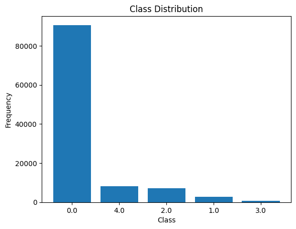

```python
import matplotlib.pyplot as plt
names = list(data.keys())
values = list(data.values())
plt.title('Class Distribution')
plt.xlabel('Class')
plt.ylabel('Frequency')
plt.bar(range(len(data)), values, tick_label=names)
plt.show()
```

No missing values anywhere.

```python
df.isnull().sum()
```

```
0      0
1      0
2      0
3      0
4      0
      ..
183    0
184    0
185    0
186    0
187    0
Length: 188, dtype: int64
```

```python
df.isnull().sum().sum()
```

```
0
```

There are 5 classes Normal beat ('N'): 0 Supraventricular ectopic beats ('S'): 1 Ventricular ectopic beats ('V'): 2 Fusion Beats ('F'): 3 Unknown Beats ('Q'): 4

```python
label = ["Normal Beat (N:0)",
         "Supraventricular (S:1)",
         "Ventricular (V:2)",
         "Fusion (F:3)",
         "Unknown (Q:4)"]
```

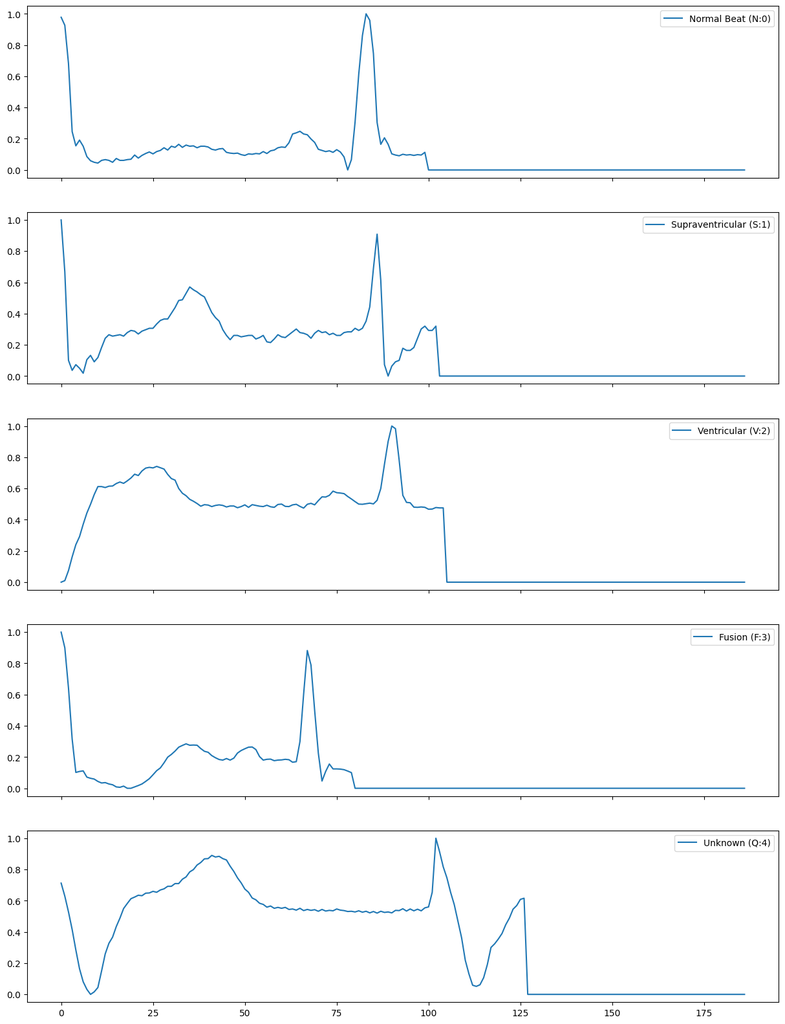

```python
import matplotlib.pyplot as plt
fig, ax = plt.subplots(5, 1, sharex=True, sharey=True,figsize=(15,20))
for i, row in enumerate(ax):
    row.plot((df[df[187] == i].iloc[0])[:-1], label=label[i])
    row.legend()
```

## Method: the split

```python
from sklearn.model_selection import train_test_split,cross_val_score
from sklearn.metrics import classification_report,accuracy_score,confusion_matrix
```

```python
X=df.iloc[:,:-1]
y=df.iloc[:,-1]
```

```python
X_train, X_test, y_train, y_test = train_test_split(X, y, test_size=0.3, random_state=28)
```

Training-set class counts before balancing.

```python
y_train.value_counts()
```

```
187
0.0    63493
4.0     5546
2.0     5075
1.0     1927
3.0      571
Name: count, dtype: int64
```

# **Unbalanced class distribution.**Hence we need to resample.

We use SMOTE *SMOTE: Synthetic Minority Over-sampling Technique*

```python
import imblearn
from imblearn.over_sampling import SMOTE
```

```python
smote=SMOTE()
X_oversampled,y_oversampled=smote.fit_resample(X_train,y_train)
```

After SMOTE every class has 63,493 training beats.

```python
y_oversampled.value_counts()
```

```
187
0.0    63493
4.0    63493
1.0    63493
2.0    63493
3.0    63493
Name: count, dtype: int64
```

```python
print(X_train.shape)
print(y_train.shape)
print(X_test.shape)
print(y_test.shape)
```

```
(76612, 187)
(76612,)
(32834, 187)
(32834,)
```

## Results: the ANN

```python
import tensorflow
from tensorflow import keras
from tensorflow.keras import Sequential
from tensorflow.keras.layers import Dense
model=Sequential()
model.add(Dense(256,activation='relu',input_dim=187))
model.add(Dense(128,activation='relu'))
model.add(Dense(64,activation='relu'))
model.add(Dense(5,activation='softmax'))
model.compile(optimizer='Adam',loss='sparse_categorical_crossentropy',metrics=['accuracy'])
```

```python
model.summary()
```

```python
##from ann_visualizer.visualize import ann_viz;
##ann_viz(model, title="ANN Visualized")
```

```python
history=model.fit(X_train,y_train,epochs=50,validation_split=0.2,batch_size=64)
```

```python
# Save only the ANN model with the highest validation accuracy
best_val_acc = max(history.history['val_accuracy'])
if not 'ann_best_acc' in globals() or best_val_acc > ann_best_acc:
    ann_best_acc = best_val_acc
    model.save('ecg_ann_best.h5')
    print(f"Saved new best ANN model with val_accuracy: {ann_best_acc:.4f}")
```

```
WARNING:absl:You are saving your model as an HDF5 file via `model.save()` or `keras.saving.save_model(model)`. This file format is considered legacy. We recommend using instead the native Keras format, e.g. `model.save('my_model.keras')` or `keras.saving.save_model(model, 'my_model.keras')`.
```

```
Saved new best ANN model with val_accuracy: 0.9820
```

```python
y_=model.predict(X_test)
y_pred=np.argmax(y_,axis=1)
```

```python
y_pred
```

Test accuracy 0.9813. Per-class precision and recall are strong except on the rare S and F classes, which is the imbalance showing.

```python
print("Accuracy with ANN is:", accuracy_score(y_test,y_pred))
print(classification_report(y_test,y_pred))
```

```
Accuracy with ANN is: 0.9812998720838155
              precision    recall  f1-score   support

         0.0       0.99      0.99      0.99     27096
         1.0       0.84      0.76      0.80       852
         2.0       0.95      0.95      0.95      2161
         3.0       0.85      0.76      0.80       232
         4.0       0.99      0.98      0.99      2493

    accuracy                           0.98     32834
   macro avg       0.92      0.89      0.91     32834
weighted avg       0.98      0.98      0.98     32834
```

Training and validation curves.

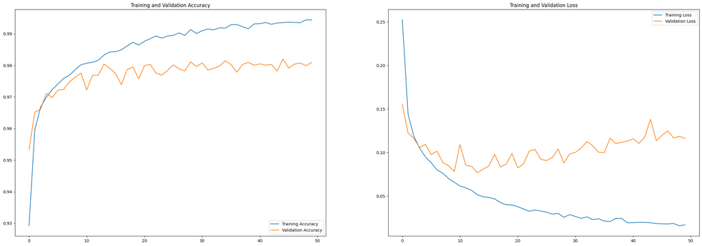

```python
acc = history.history['accuracy']
val_acc = history.history['val_accuracy']

loss = history.history['loss']
val_loss = history.history['val_loss']

epochs_range = range(50)

plt.figure(figsize=(30, 10))
plt.subplot(1, 2, 1)
plt.plot(epochs_range, acc, label='Training Accuracy')
plt.plot(epochs_range, val_acc, label='Validation Accuracy')
plt.legend(loc='lower right')
plt.title('Training and Validation Accuracy')

plt.subplot(1, 2, 2)
plt.plot(epochs_range, loss, label='Training Loss')
plt.plot(epochs_range, val_loss, label='Validation Loss')
plt.legend(loc='upper right')
plt.title('Training and Validation Loss')
plt.show()
```

Confusion matrix on the test set.

```python
cf_matrix = confusion_matrix(y_test, y_pred)
print(cf_matrix)
```

```
[[26890   108    62    15    21]
 [  191   646    11     1     3]
 [   79     6  2058    15     3]
 [   37     0    19   176     0]
 [   27     6    10     0  2450]]
```

```python
import numpy as np


def plot_confusion_matrix(cm,
                          target_names,
                          title='Confusion matrix',
                          cmap=None,
                          normalize=True):
    """
    given a sklearn confusion matrix (cm), make a nice plot

    Arguments
    ---------
    cm:           confusion matrix from sklearn.metrics.confusion_matrix

    target_names: given classification classes such as [0, 1, 2]
                  the class names, for example: ['high', 'medium', 'low']

    title:        the text to display at the top of the matrix

    cmap:         the gradient of the values displayed from matplotlib.pyplot.cm
                  see http://matplotlib.org/examples/color/colormaps_reference.html
                  plt.get_cmap('jet') or plt.cm.Blues

    normalize:    If False, plot the raw numbers
                  If True, plot the proportions

    Usage
    -----
    plot_confusion_matrix(cm           = cm,                  # confusion matrix created by
                                                              # sklearn.metrics.confusion_matrix
                          normalize    = True,                # show proportions
                          target_names = y_labels_vals,       # list of names of the classes
                          title        = best_estimator_name) # title of graph

    Citiation
    ---------
    http://scikit-learn.org/stable/auto_examples/model_selection/plot_confusion_matrix.html

    """
    import matplotlib.pyplot as plt
    import numpy as np
    import itertools

    accuracy = np.trace(cm) / float(np.sum(cm))
    misclass = 1 - accuracy

    if cmap is None:
        cmap = plt.get_cmap('Blues')

    plt.figure(figsize=(12, 8))
    plt.imshow(cm, interpolation='nearest', cmap=cmap)
    plt.title(title)
    plt.colorbar()

    if target_names is not None:
        tick_marks = np.arange(len(target_names))
        plt.xticks(tick_marks, target_names, rotation=45)
        plt.yticks(tick_marks, target_names)

    if normalize:
        cm = cm.astype('float') / cm.sum(axis=1)[:, np.newaxis]


    thresh = cm.max() / 1.5 if normalize else cm.max() / 2
    for i, j in itertools.product(range(cm.shape[0]), range(cm.shape[1])):
        if normalize:
            plt.text(j, i, "{:0.4f}".format(cm[i, j]),
                     horizontalalignment="center",
                     color="white" if cm[i, j] > thresh else "black")
        else:
            plt.text(j, i, "{:,}".format(cm[i, j]),
                     horizontalalignment="center",
                     color="white" if cm[i, j] > thresh else "black")


    plt.tight_layout()
    plt.ylabel('True label')
    plt.xlabel('Predicted label\naccuracy={:0.4f}; misclass={:0.4f}'.format(accuracy, misclass))
    plt.show()
```

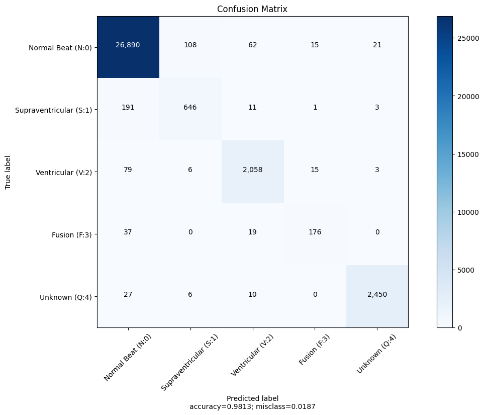

```python
plot_confusion_matrix(cf_matrix,
                      normalize    = False,
                      target_names = ["Normal Beat (N:0)",
                                         "Supraventricular (S:1)",
                                         "Ventricular (V:2)",
                                         "Fusion (F:3)",
                                         "Unknown (Q:4)"],
                      title        = "Confusion Matrix")
```